# Project 1

Dr. Wayne Stewart

2018-09-20

# 1 Introduction to the data

## 1.2 Summary Table

| MODEL PREDICTS DEFECTS | MODULE HAS DEFECTS |  |
| --- | --- | --- |
|  | FALSE | TRUE |
| No | a | b |
| Yes | c | d |

Using $\LaTeX$ construct the formulae for

1. Accuracy
2. Detection rate
3. False alarm rate
4. Precision

Latex Example: See (http://www.stat.cmu.edu/~cshalizi/rmarkdown/#elements-of-math-mode)

# 2 R functions

Using the above definitions make R functions that will create the required probabilities, please remove `eval=FALSE` when creating the functions :

```r
acc=function(a,b,c,d)
{

}
```

```r
detect=function(b,d)
{

}
```

```r
falarm=function(a,c)
{

}
```

```r
prec=function(c,d)
{

}
```

# 3 Create the tables in Figure SIA3.1

The tables do not have to be formatted exactly as those in the book. Have the functions produce a suitable barplot alse.

As a guide and help – see code below

```r
swd=read.csv("C:/Users/Adrienne/Dropbox/R/lab1/swdefects.csv")
head(swd)
```

|  | Mloc | Mvg | Mevg | Mivg | Hn | Hvol | Hpgmlen | Hdiff | Hintell | Heffort | Hb | Htime | Hloc | Hcomm | Hblank | loc.comm | uniOp | uniOpnd | totOp | totOpnd | brnchcnt | defect | predict.vg.10 | predict.evg.14.5 | predict.ivg.9.2 | predict.loc.50 |
| --- | --- | --- | --- | --- | --- | --- | --- | --- | --- | --- | --- | --- | --- | --- | --- | --- | --- | --- | --- | --- | --- | --- | --- | --- | --- | --- |
| 1 | 1.1 | 1.4 | 1.4 | 1.4 | 1.3 | 1.3 | 1.30 | 1.30 | 1.30 | 1 | 1.30 | 1 | 2 | 2 | 2 | 2 | 1.2 | 1.2 | 1.2 | 1.2 | 1.4 | FALSE | no | no | no | no |
| 2 | 1.0 | 1.0 | 1.0 | 1.0 | 1.0 | 1.0 | 1.00 | 1.00 | 1.00 | 1 | 1.00 | 1 | 1 | 1 | 1 | 1 | 1.0 | 1.0 | 1.0 | 1.0 | 1.0 | TRUE | no | no | no | no |
| 3 | 24.0 | 5.0 | 1.0 | 3.0 | 63.0 | 309.1 | 0.11 | 9.50 | 32.54 | 2937 | 0.10 | 163 | 1 | 0 | 6 | 0 | 15.0 | 15.0 | 44.0 | 19.0 | 9.0 | FALSE | no | no | no | no |
| 4 | 20.0 | 4.0 | 4.0 | 2.0 | 47.0 | 215.5 | 0.06 | 16.00 | 13.47 | 3448 | 0.07 | 192 | 0 | 0 | 3 | 0 | 16.0 | 8.0 | 31.0 | 16.0 | 7.0 | FALSE | no | no | no | no |
| 5 | 24.0 | 6.0 | 6.0 | 2.0 | 72.0 | 346.1 | 0.06 | 17.33 | 19.97 | 6000 | 0.12 | 333 | 0 | 0 | 3 | 0 | 16.0 | 12.0 | 46.0 | 26.0 | 11.0 | FALSE | no | no | no | no |
| 6 | 24.0 | 6.0 | 6.0 | 2.0 | 72.0 | 346.1 | 0.06 | 17.33 | 19.97 | 6000 | 0.12 | 333 | 0 | 0 | 3 | 0 | 16.0 | 12.0 | 46.0 | 26.0 | 11.0 | FALSE | no | no | no | no |

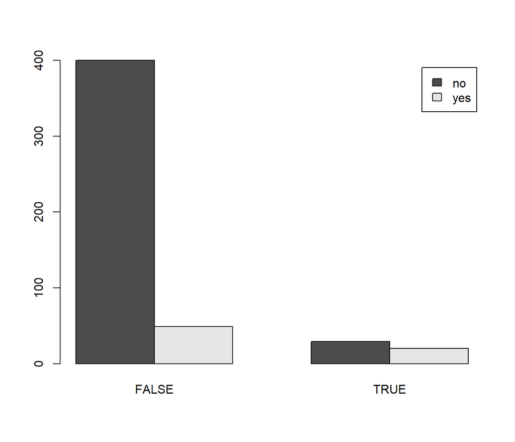

```r
tab=with(swd, table(predict.loc.50,defect))
barplot(tab, beside=TRUE, leg=TRUE)
```

```r
tab2=addmargins(tab)
tab2
```

```
##               defect
## predict.loc.50 FALSE TRUE Sum
##            no    400   29 429
##            yes    49   20  69
##            Sum   449   49 498
```

# 4 Create the table on page 127, TABLE SIA3.3

You must create a function that will do this. That is the table should be made by invocation of the function. You may write your own code from scratch – make sure it is hash commented. Below is a help (remember: you can make the function as you wish) – you can use the previously made functions in this function also. More precisely the function must make:

> 1. The Table
> 2. A suitable barplot

```r
allmethods = function(df) # dataframe
{
  # tabloc = table()
  # tabvg = table()
  # tabevg = table()
  # tabivg = table()

  probs=c("Accuracy","Detection Rate","False Alarm Rate", "Precision")
  mths = c("Lines of Code", "Cyclomatic complexity", "Essential complexity", "Design complexity")

  alltab = matrix(NA,nr=4,nc=4,dimnames=list(mths,probs) )


  as.table(alltab)
}

allmethods(df = swd)
```

[output not shown]